# Class 6: Genomic Analysis Pt I

Neelanjan Mukherjee

03/06/2019

## Background info

#### ELAVL1 or HuR is an essential RNA-binding protein (RBPs).

It binds to AU-rich elements (ARE) in 3’ UTRs of mRNAs. This results in stabilization of the target mRNA. See below for a model for how multiple RBPs bind to the TNF mRNA ARE to control its stability.

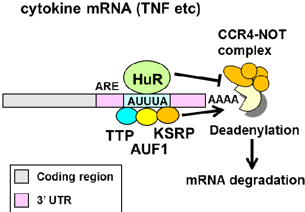

#### PAR-CLIP is method to map RBP-RNA interaction sites.

As described below, 4sU-labeled transcripts are crosslinked to RBPs and partially digested RNA-protein complexes are immunopurified and size-fractionated. RNA molecules are recovered, converted to a cDNA library and sequenced.

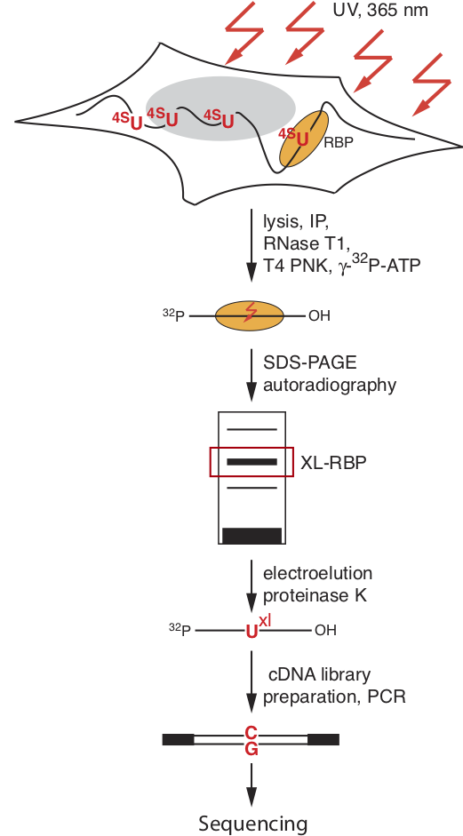

## Hypothesis:

## *HuR binds to AU-rich elements in the 3’ UTR of mRNAs to promote stability.*

Below are specific questions that test this model:

### A. Examine types of HuR binding site

#### Which regions are enriched for HuR binding?

### B. Examine HuR binding sequence specificity

#### What sequences does HuR bind to?

#### Are those sequences enriched for HuR binding compared to background?

### C. How does HuR binding relate to target RNA stability

#### Does HuR promote the stability of its mRNA targets?

#### Does the region HuR bind to influence stabilization?

#### Does the number of HuR binding sites per target influence stabilization?

### A. Examine HuR binding site patterns

#### Where does HuR bind?

For the purpose of this exercise we will be focus on mRNAs to keep it simple.

```r
# read in HuR binding sites
hur_parclip <- read_tsv("data/input/SRR248532_clusters.tsv.zip")
# we are going to modify 5'utr and 3'utr to make things easier
hur_parclip$Aligned.to <- gsub("5'utr", "utr5", hur_parclip$Aligned.to)
hur_parclip$Aligned.to <- gsub("3'utr", "utr3", hur_parclip$Aligned.to)

# let's look at the annotation categories that HuR binds to
binding_regions_all <- hur_parclip %>%
  count(Aligned.to) %>%
  arrange(desc(n)) %>%
  mutate(freq=n/sum(n))
binding_regions_all
```

```
## # A tibble: 39 x 3
##    Aligned.to                  n    freq
##    <chr>                   <int>   <dbl>
##  1 intron                  60846 0.547
##  2 utr3                    20490 0.184
##  3 NoAnnotation            18694 0.168
##  4 processed_transcript     2621 0.0236
##  5 repeat                   2277 0.0205
##  6 lincRNA_intron           1813 0.0163
##  7 antisense                1220 0.0110
##  8 coding                    825 0.00742
##  9 lincRNA_exon              495 0.00445
## 10 nonsense_mediated_decay   431 0.00387
## # ... with 29 more rows
```

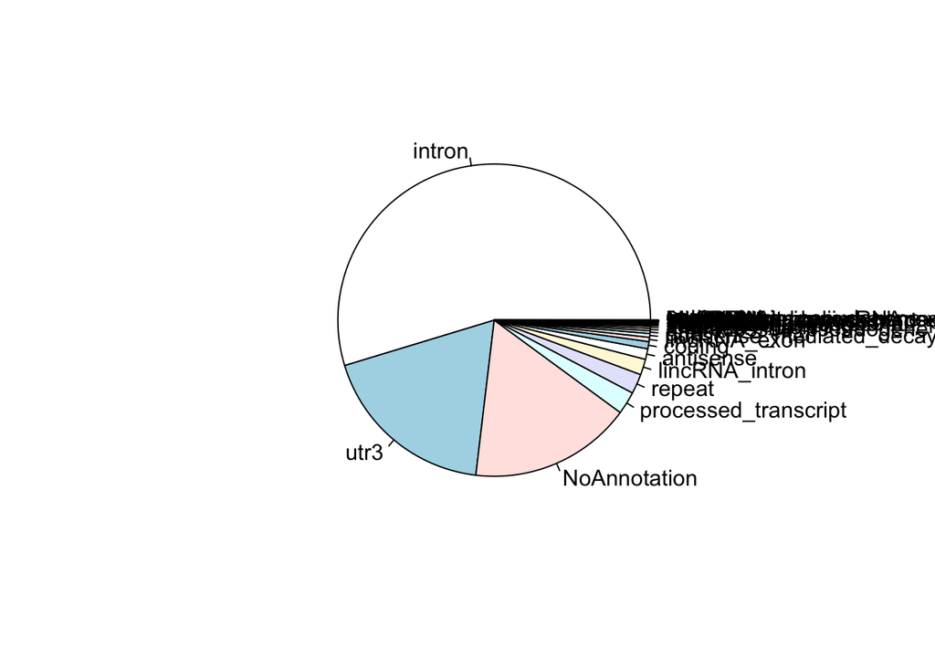

```r
# I hate pie charts - they may be the single worst way to convey information
pie(x = binding_regions_all$n, labels = binding_regions_all$Aligned.to)
```

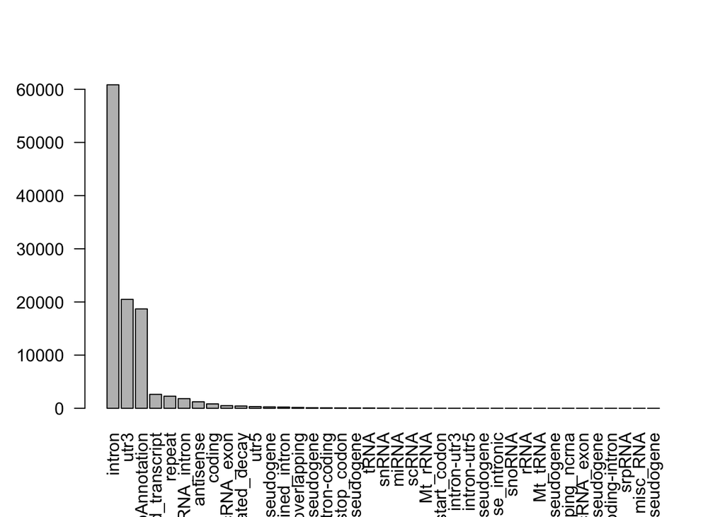

```r
barplot(binding_regions_all$n, names.arg = binding_regions_all$Aligned.to, las=2)
```

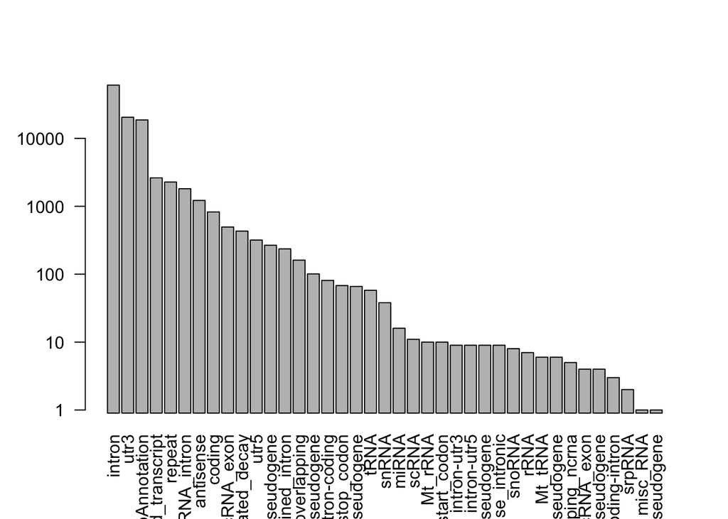

```r
barplot(binding_regions_all$n, names.arg = binding_regions_all$Aligned.to, las=2, log = "y")
```

```r
# that is a lot so we will limit analysis to binding sites in mRNA
# so we are going to create a list of the
# annotation  regions of interest





mRNA_regions <- c("utr5","coding","intron", "utr3")


hur_parclip %>%
  filter(Aligned.to %in% mRNA_regions) %>%
  count(Aligned.to) %>%
  summarise(fraction_mRNA=sum(n)/nrow(hur_parclip))
```

```
## # A tibble: 1 x 1
##   fraction_mRNA
##           <dbl>
## 1         0.741
```

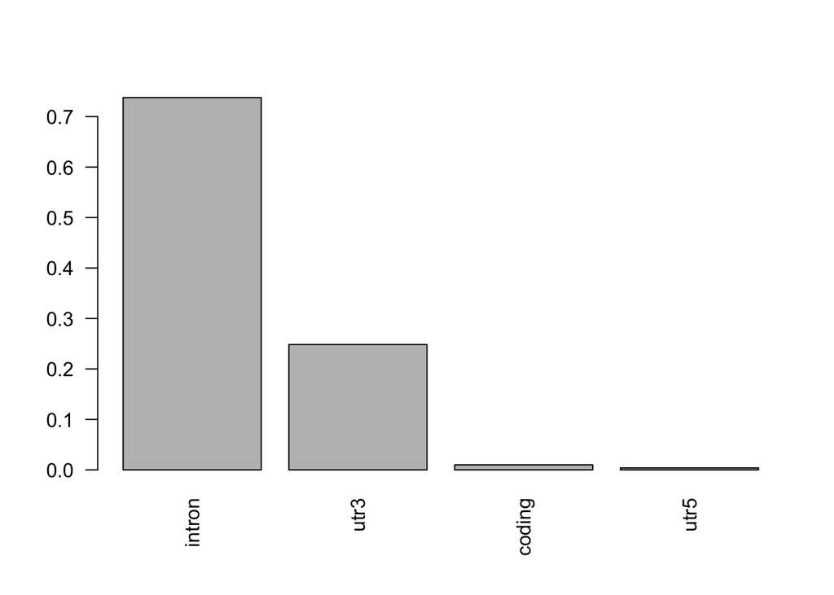

```r
# we are excluding ~26% of the binding sites by restricting to mRNA
# most of those are unannotated

hur_parclip_mRNA <- hur_parclip %>%
  filter(Aligned.to %in% mRNA_regions)

binding_regions_mRNA <- hur_parclip_mRNA %>%
  count(Aligned.to) %>%
  arrange(desc(n)) %>%
  mutate(freq=n/sum(n))

barplot(binding_regions_mRNA$freq, names.arg = binding_regions_mRNA$Aligned.to, las=2)
```

```r
intron_utr_hursites <- binding_regions_mRNA[1,2]/binding_regions_mRNA[2,2]

intron_utr_hursites <- round(intron_utr_hursites, digits = 2)
```

The majority of HuR binding sites are in introns and 3’ UTRs. About 3/4 of HuR binding sites are in introns and 1/4 in 3’ UTRs.

#### Which regions are enriched for HuR binding?

There are 2.97x more binding sites in intron vs 3’ UTR. This would suggest that HuR preferentially binds to introns. However introns are much longer than 3’ UTRs. So if the average intron is 3x longer than the average 3’UTR - then HuR would exhibit simialr binding preference. We need to figure the length of introns and 3’ UTRs. In order to do this we need a couple things.

- We will need gene/transcript models. This information is available in GFF/GTF files. We will use one from [GENCODE](https://www.gencodegenes.org/human/release_19.html).
- We need the human genome.

```r
if (!file.exists("data/accessories/gencodev19.sqlite")) {
  df <- read.csv2(f, TRUE, stringsAsFactors=FALSE)

  txdb <- makeTxDbFromGFF("ftp://ftp.ebi.ac.uk/pub/databases/gencode/Gencode_human/release_19/gencode.v19.annotation.gtf.gz", format="gtf")

  saveDb(txdb,file="data/accessories/gencodev19.sqlite")
}

# load the gencode v19 txdb
txdb <- loadDb("data/accessories/gencodev19.sqlite")

introns <- intronsByTranscript(txdb)
introns <- reduce(unlist(introns))


utr3  <- threeUTRsByTranscript(txdb)

utr3 <- reduce(unlist(utr3))


summary(width(utr3))
```

```
##    Min. 1st Qu.  Median    Mean 3rd Qu.    Max.
##     1.0    89.0   149.0   588.1   473.0 22552.0
```

```r
summary(width(introns))
```

```
##    Min. 1st Qu.  Median    Mean 3rd Qu.    Max.
##       1     556    1739    8244    5276 1552226
```

```r
intron_utr3_median <- median(width(introns)) / median(width(utr3))
intron_utr3_median <- round(intron_utr3_median, digits = 2)

intron_utr3_sum <- sum(width(introns))/sum(width(utr3))
intron_utr3_sum <- round(intron_utr3_sum, digits = 1)
```

The median intron length is 11.67x longer than median 3’ UTR length. Therefore, based on median region length HuR is 4x more likely to bind in 3’ UTRs than introns.

There is 40.3x more intronic nucleotides than 3’ UTR nucleotides. Therefore, based on total region length HuR is 14x more likely to bind in 3’ UTRs than introns.

### B. Examine HuR binding sequence specificity

#### What sequences does HuR bind to?

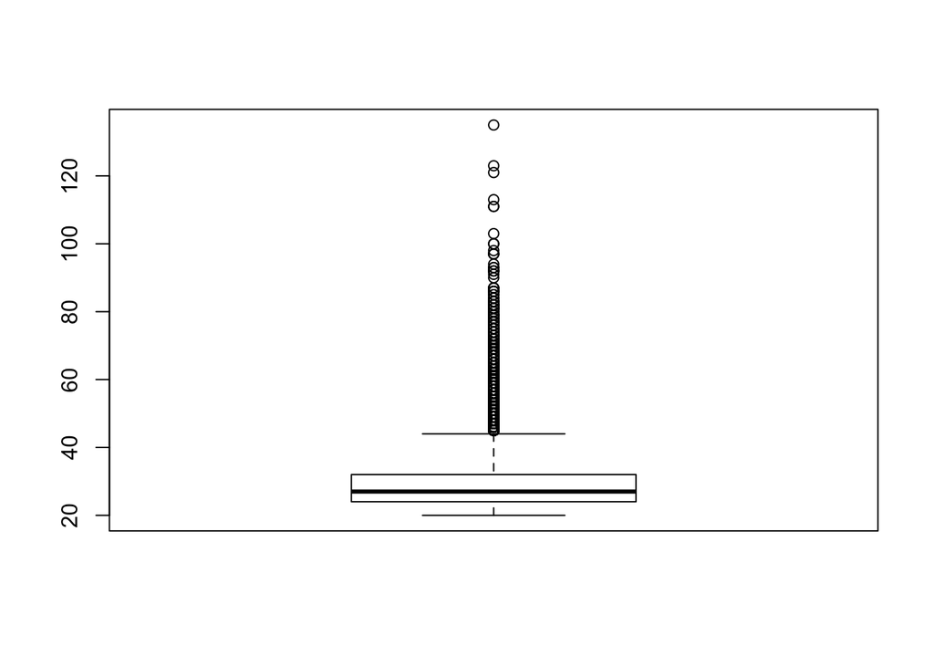

```r
hur_string <- DNAStringSet(hur_parclip_mRNA$ClusterSequence)
names(hur_string) <- hur_parclip_mRNA$Aligned.to

boxplot(width(hur_string))
```

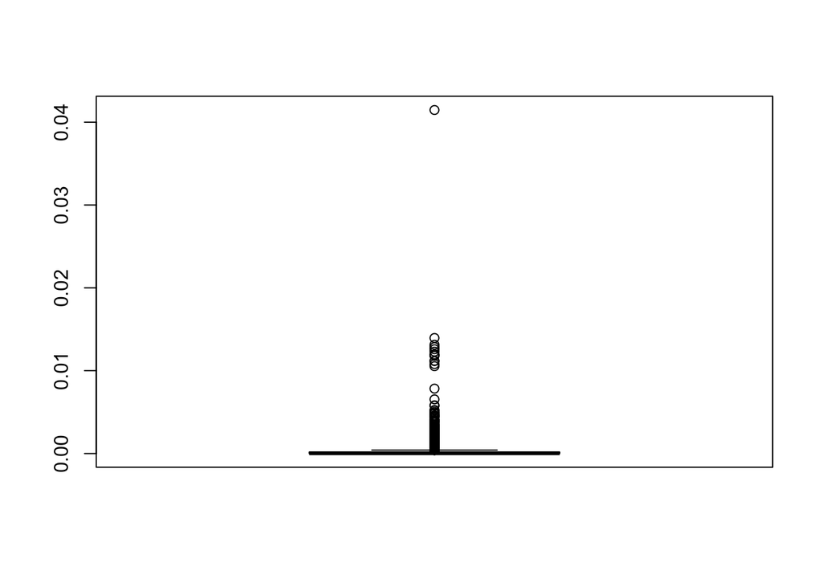

```r
hur_6mer <- data.frame(
  count=oligonucleotideFrequency(x = unlist(hur_string), width = 6)
  )

hur_6mer$nuc <- rownames(hur_6mer)
hur_6mer$freq <- hur_6mer$count/sum(hur_6mer$count)
hur_6mer$freq_rand <- hur_6mer$freq/(1/4096)
hur_6mer <- hur_6mer %>% arrange(desc(count))


boxplot(hur_6mer$freq)
```

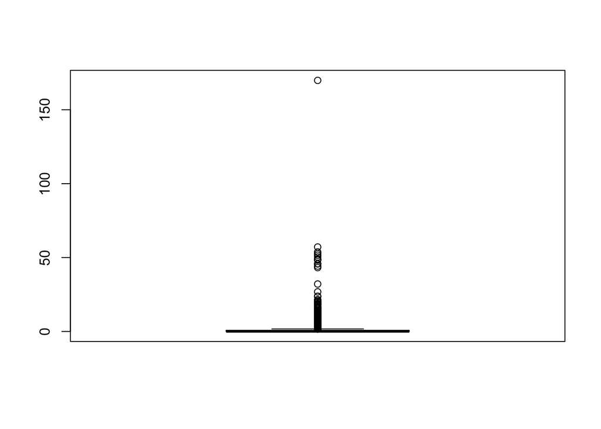

```r
boxplot(hur_6mer$freq_rand)
```

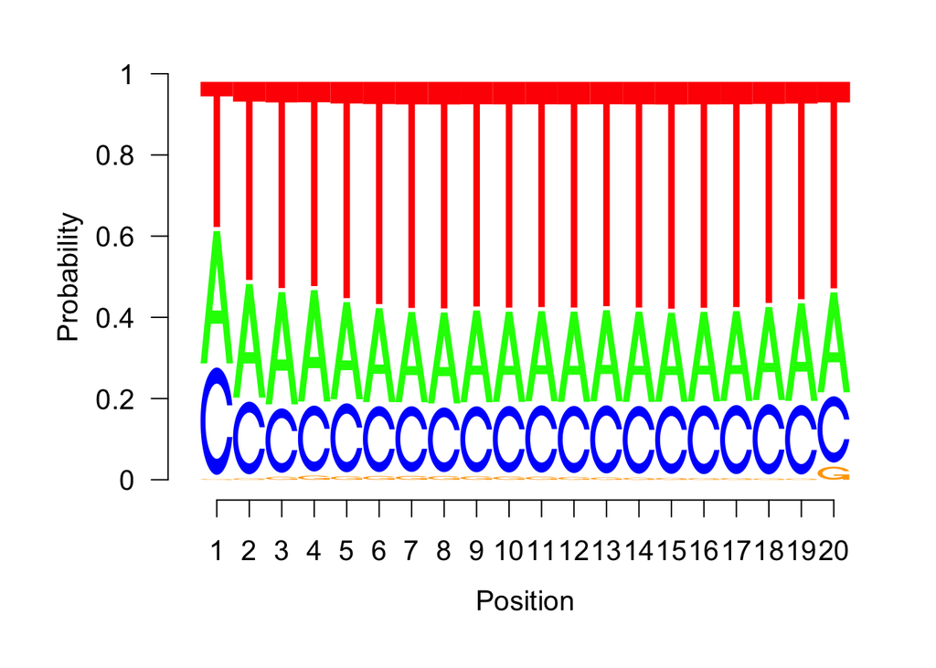

```r
good6mers <- hur_6mer %>% filter(freq_rand > 20)


hur_string_20 <- DNAStringSet(hur_string, end=20) # only keeping the first 20 nucleotides

letter_counts <- consensusMatrix(hur_string_20)
probs <- prop.table(letter_counts[1:4,], 2)

seqLogo(probs, ic.scale = F)
```

So we now know that HuR really likes TTTTTT, which is really UUUUUU - perhaps even better than it likes AUUUUA.

|  | count | nuc | freq | freq_rand |
| --- | --- | --- | --- | --- |
| 1 | 98656 | TTTTTT | 0.0414688974862087 | 169.856604103511 |
| 2 | 33179 | TTATTT | 0.0139464051826034 | 57.1244756279434 |
| 3 | 31232 | TTTATT | 0.0131280064698475 | 53.7723145004952 |
| 4 | 30570 | ATTTTT | 0.012849742500744 | 52.6325452830474 |
| 5 | 29935 | TATTTT | 0.0125828276663321 | 51.5392621212962 |
| 6 | 29263 | TTTTTA | 0.0123003603140095 | 50.3822758461831 |
| 7 | 28455 | TTTTCT | 0.0119607269499074 | 48.9911375868209 |
| 8 | 28170 | TTTCTT | 0.0118409305281635 | 48.5004514433577 |
| 9 | 28068 | TTTTTC | 0.0117980560193288 | 48.3248374551709 |
| 10 | 26626 | TTCTTT | 0.0111919281591367 | 45.842137739824 |

[output cut: 4086 more lines]

But we need to normalize for the frequency of these sequences in 3’ UTRs and introns. For this task we need to retrieve the sequences for introns and 3’ UTRs.

#### Are those sequences enriched for HuR binding compared to background?

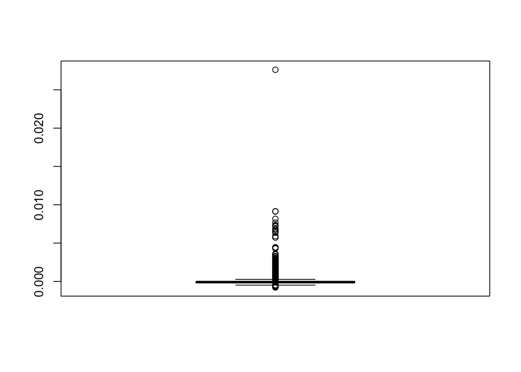

```r
# let's get 3' UTR sequences
threeUTR_seqs <- getSeq(BSgenome.Hsapiens.UCSC.hg19, utr3)

threeUTR_seqs <- DNAStringSet(unlist(threeUTR_seqs))

hur_string_utr3 <- hur_string[names(hur_string) == "utr3"]


utr3_6mer <- data.frame(
  countHuR=oligonucleotideFrequency(x = unlist(hur_string_utr3), width = 6, as.prob = T),
  countUTRs=oligonucleotideFrequency(x = unlist(threeUTR_seqs), width = 6, as.prob = T)
  )

utr3_6mer$k <- rownames(utr3_6mer)
utr3_6mer$utr_pref <- utr3_6mer$countHuR - utr3_6mer$countUTRs
utr3_6mer$utr_pref_fold <- utr3_6mer$countHuR/utr3_6mer$countUTRs
utr3_6mer <- utr3_6mer %>% arrange(desc(utr_pref))

boxplot(utr3_6mer$utr_pref)
```

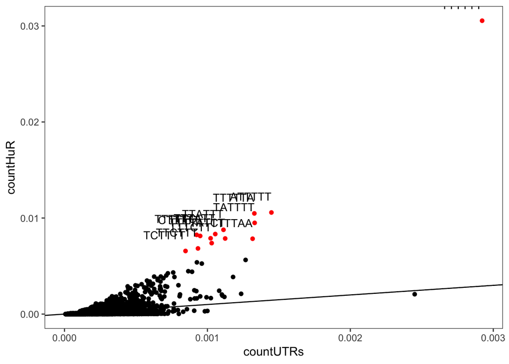

```r
ggplot(data = utr3_6mer, aes(y = countHuR, x = countUTRs)) +
  geom_point(color = ifelse(utr3_6mer$utr_pref > .005, "red", "black")) +
  theme_few() +
  geom_abline(intercept = 0, slope = 1) +
  geom_text(aes(label=ifelse(utr3_6mer$utr_pref > .005,
                             utr3_6mer$k,
                             "")
                )
            ,hjust=1,vjust=-1.5)
```

In this analysis we focuesed on HuR binding sites in 3’ UTRs. We asked which 6mers were most enriched in the HuR 3’ UTR binding sites compared to the 6mer frequency in all 3’ UTRs. We again found U-rich stetches separated by A and C appear to be preferrentially enriched by HuR.

|  | countHuR | countUTRs | k | utr_pref | utr_pref_fold |
| --- | --- | --- | --- | --- | --- |
| 1 | 0.0305436674112063 | 0.00292211450477979 | TTTTTT | 0.0276215529064265 | 10.4525908759718 |
| 2 | 0.0104805734380294 | 0.00132838238461677 | TTTTTA | 0.00915219105341264 | 7.88972630125097 |
| 3 | 0.0105776157846778 | 0.00144777062061002 | ATTTTT | 0.00912984516406782 | 7.30614065107976 |
| 4 | 0.0094969916872539 | 0.00133050109823393 | TATTTT | 0.00816649058901997 | 7.13790593623708 |
| 5 | 0.00877493083676819 | 0.00111245228235744 | TTATTT | 0.00766247855441075 | 7.88791661083466 |
| 6 | 0.00824859946511574 | 0.000924575990522866 | TTTTTC | 0.00732402347459288 | 8.92149433866544 |
| 7 | 0.00833248352747285 | 0.0010549151679831 | TTTATT | 0.00727756835948975 | 7.8987237840212 |
| 8 | 0.0081367540486396 | 0.000949413440516758 | CTTTTT | 0.00718734060812284 | 8.57029582834937 |
| 9 | 0.00789168100371393 | 0.00102218997693257 | TTTTAT | 0.00686949102678136 | 7.72036625461308 |
| 10 | 0.00787029879174054 | 0.0011241945505971 | TTTTCT | 0.00674610424114344 | 7.00083343008586 |

[output cut: 4086 more lines]

## For homework determine which 6mers are detected at a higher frequency in intronic HuR binding sites compared to their frequency in introns.

### C. How does HuR binding relate to target RNA stability

#### Does HuR promote the stability of its mRNA targets?

One common way to visualize differences in the distribution of a variable based on category os a [cdf plot](https://ggplot2.tidyverse.org/reference/stat_ecdf.html). Often the x-axis is the log-fold change upon knockdown/overexpresion of protein and we want to see show different sets of genes behave in this context. You will be asked to make cdf plots comparing HuR knockdown accross dofferent catgories.

```r
load("data/input/HuR.R") # read in HuR knockdown data

hur_sirna <- HuR[rowSums(HuR) > 4,] # filter low expression

hur_sirna$Gene <- rownames(hur_sirna)


geneInfo <- read_csv("data/input/geneInfo.csv.zip")[,c(2,11)] # gene id mapping
```

```
## Multiple files in zip: reading 'geneInfo.csv'
```

```r
hur_siRNA <- right_join(geneInfo, hur_sirna)
```

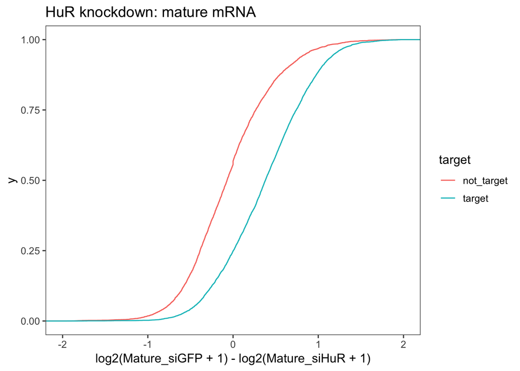

```r
hur_mRNA <- hur_parclip_mRNA %>%
  count(GeneName,Aligned.to) %>%
  spread(Aligned.to,n) %>%
  arrange(desc(utr3))

hur_mRNA[is.na(hur_mRNA)] <- 0 # replace these NA values with zeroes

hur_mRNA$total <- rowSums(hur_mRNA[,2:5])
hur_mRNA$target <- rep("target",nrow(hur_mRNA))
colnames(hur_mRNA)[1] <- "Symbol"

hur_sirna_binding <- left_join( hur_siRNA, hur_mRNA, by = "Symbol")[,-1]
colnames(hur_sirna_binding)[1] <- "Gene"

hur_sirna_binding$target[is.na(hur_sirna_binding$target)] <- "not_target"

hur_sirna_binding <- hur_sirna_binding[!is.na(hur_sirna_binding$Gene),]

ggplot(hur_sirna_binding, aes(x = log2(Mature_siGFP+1) - log2(Mature_siHuR+1), color = target)) +
  stat_ecdf() +
  theme_few() +
  xlim(-2,2) +
  ggtitle("HuR knockdown: mature mRNA")
```

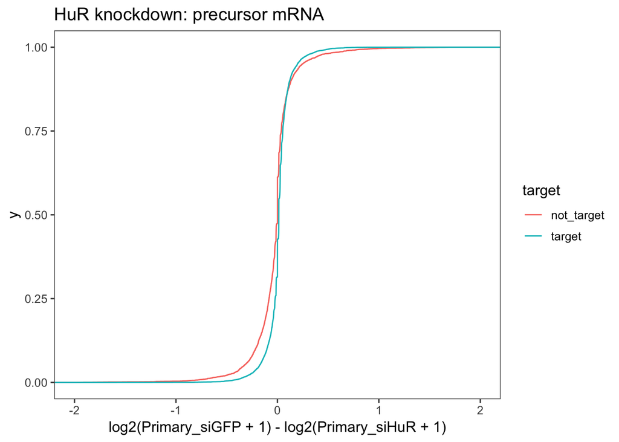

```r
ggplot(hur_sirna_binding, aes(x = log2(Primary_siGFP+1) - log2(Primary_siHuR+1), color = target)) +
  stat_ecdf() +
  theme_few() +
  xlim(-2,2) +
  ggtitle("HuR knockdown: precursor mRNA")
```

#### Does the region HuR bind to influence stabilization?

```r
# make a new column that indicates whether a gene has a 3' UTR, intron, 3' UTR intron or other combination site

# use this column to make a cdf plot
```

#### Does the number of HuR binding sites per target influence stabilization?

```r
hur_sirna_binding$intron_bin <- cut2(x = hur_sirna_binding$intron, g = 4 )
levels(hur_sirna_binding$intron_bin)
```

```
## [1] "[0,  2)" "[2,  4)" "[4,  9)" "[9,266]"
```

```r
hur_sirna_binding$intron_bin <- recode_factor(hur_sirna_binding$intron_bin,
              "[0,  2)" = "0-2",
              "[2,  4)" = "2-4",
              "[4,  9)" = "4-9",
              "[9,266]" = "9+"
              )

# now make the same cdf plot as above except for color by 'intron_bin'

# does this relationship hold true for 3' UTRs?
```